# Time Series Exploratory Data Analysis

With time series data, it is the dependence between the values of the series that is important to measure; we must, at least, be able to estimate autocorrelations with precision.

It would be diﬃcult to measure that dependence if the dependence structure is not regular or is changing at every time point. Hence, to achieve any meaningful statistical analysis of time series data, it will be crucial that the mean and the autocovariance functions satisfy the conditions of stationarity.

## Interpolation

In many cases, we will have unknown values during our sampling process. Usually, we approximate those missing values with a reasonable value obtained from the data points around it; in the time series analysis, that could be a valid value. That is the interpolation process.

*Understanding the problem is essential to decide the best interpolation method.*

### Linear Interpolation

In mathematics, linear interpolation is a method of curve fitting using linear polynomials to construct new data points within the range of a discrete set of known data points.

If the two known points are given by the coordinates $(t_0, X_{t_0})$ and $(t_1, X_{t_1})$, the linear interpolant is the straight line between these points. For a value $X_t$ in the interval $(t_0, t_1)$, the value $X_t$ along the straight line is given from the equation of slopes

$$ \frac{X_t - X_{t_0}}{t-t_0}=\frac{X_{t_1} - X_{t_0}}{t_1-t_0} $$

Solving this equation for $X_t$, which is the unknown value at $t$, gives

$$ X_t=\frac{X_{t_0}(t_1 - t) + X_{t_1}(t - t_0)}{t_1 - t_0} $$

```python
print("The time series contains {} null values.".format(time_series.isna().sum()))
time_series.interpolate(method="linear", inplace=True)
print("After interpolation the time series contains {} null values.".format(time_series.isna().sum()))
```

```
The time series contains 10 null values.
After interpolation the time series contains 0 null values.
```

## Variance Stabilization

Often, obvious aberrations are present that can contribute nonstationary as well as nonlinear behavior in observed time series. In such cases, transformations may be useful to equalize the variability over the length of a single series. A particularly useful transformation is

$$ Y_t = log X_t , $$

which tends to suppress larger fluctuations that occur over portions of the series where the underlying values are larger.

### Example of Log Transformation

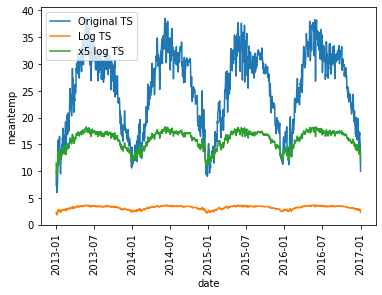

```python
ax.figure
```

### Power Transformations

Other possibilities for variance stabilization are power transformations in the Box-Cox family of the form

$$ Y_t = \begin{cases} \frac{X_t^\lambda - 1}{\lambda} & \lambda \neq 0 \\ log(X_t) & \lambda=0 \end{cases} $$

Often, transformations are also used to improve the approximation to normality or to improve linearity in predicting the values of one series from antoher.

## Smoothing

Smoothing a time series is useful in discovering certain traits in a time series, such as long-term trend an seasonal components. As we seen before, we can smooth a time series in a basic version using the moving average smoother.

$$ M_t = \sum_{j=-k}^k a_j X_{t-j} $$

where $a_j = a_{-j} \geq 0$ and $\sum_{j=-k}^k a_j = 1$ is a symetric moving average of the data.

### Kernel Smoothing

Kernel smoothing is a moving average smoother that uses a weight function, or kernel, to average the observations, it is

$$ M_t = \sum_{i=1}^{T} w_i(t) X_i $$

where

$$ w_i(t) = \frac{K\left(\frac{t-i}{b}\right)}{ \sum_{j=1}^{T} K\left(\frac{t-j}{b}\right)} $$

are the weights and $K(\cdot)$ is a kernel function.

### Example of Kernel Smoothing

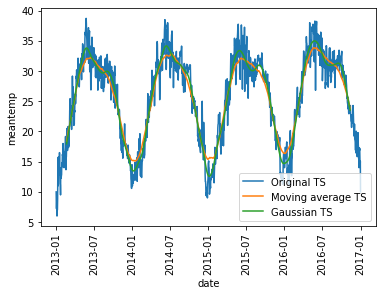

```python
ax.figure
```

### LOWESS

Another approach to smoothing a time plot is nearest neighbor regression. The technique is based on k-nearest neighbors regression, wherein one uses only the data $\{X_{t−k/2} , . . . , X_t , . . . , X_{t+k/2} \}$ to predict $X_t$ via regression.

Lowess is a method of smoothing that is rather complex, but the basic idea is close to nearest neighbor regression.

### Example of LOWESS

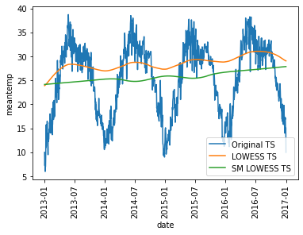

```python
ax.figure
```

## Nonlinear Relations

To check for nonlinear relations of this form, it is convenient to display a lagged scatterplot matrix. Superimposed on the scatterplots are locally weighted scatterplot smoothing (lowess) lines that can be used to help discover any nonlinearities.

We might want to look at values of one series against another series at various lags to look for possible nonlinear relations between the two series.

### Example of Scatterplots

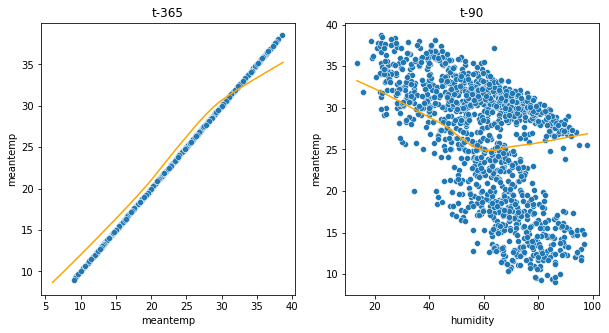

```python
figure
```

## Stationarity

Stationarity is an important concept in time series analysis.

- Stationarity means that the statistical properties of a time series (or rather the process generating it) do not change over time.
- Stationarity is important because many useful analytical tools and statistical tests and models rely on it.

As such, the ability to determine if a time series is stationary is important. Rather than deciding between two strict options, this usually means being able to ascertain, with high probability, that a series is generated by a stationary process.

### Looking at the Data

The most basic methods for stationarity detection rely on plotting the data, or functions of it, and determining visually whether they present some known property of stationary (or non-stationary) data.

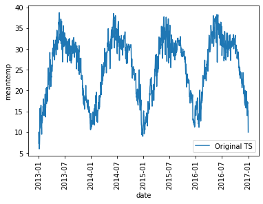

```python
ax.figure
```

### Looking at Autocorrelation Function (ACF) Plots

When plotting the value of the ACF for increasing lags, the values tend to degrade to zero quickly for stationary time series, while for non-stationary data the degradation will happen more slowly.

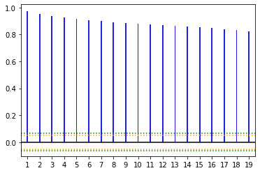

```python
ax.figure
```

## Removing Trends

As mentioned before, the stationarity property is useful in the time series analysis, then we need some tools that could help us to achive this in a non-stationary time series.

### Trend Stationary

Perhaps the easiest form of nonstationarity to work with is the trend stationary model wherein the process has stationary behavior around a trend. We may write this type of model as

$$ X_t = \mu_t + Y_t $$

where $X_t$ are the observations, $\mu_t$ denotes the trend, and $Y_t$ is a stationary process. Quite often, strong trend will obscure the behavior of the stationary process, $Y_t$, hence, there is some advantage to removing the trend as a ﬁrst step in an exploratory analysis of such time series.

We might model trend as a stochastic component using the random walk with drift model

$$ \mu_t = \delta + \mu_{t-1} + W_t $$

If the appropriate model is $X_t = \mu_t + Y_t$, then diﬀerencing the data, $X_t$, yields a stationary process;

$$ X_t - X_{t-1} = (\mu_t + Y_t) - (\mu_{t-1} + Y_{t-1}) \\ = (\delta + \mu_{t-1} + W_t + Y_t) - (\mu_{t-1} + Y_{t-1}) \\ = \delta + W_t + Y_t - Y_{t-1} $$

where $Y_t - Y_{t-1}$ is a stationary process.

### Example of Trend Stationary

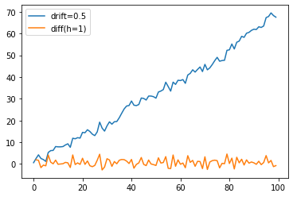

```python
ax.figure
```

## Seasonal Stationary

Another kind of nonstationarity is a seasonal behavior. We may write this type of model as before

$$ X_t = \mu_t + Y_t $$

but in this case, we might model the trend as a stochastic component using the signal in noise model

$$ \mu_t = A cos\left(2 \pi \omega t + \phi \right) = A cos\left(2 \pi \omega \left[t - \frac{1}{\omega} \right] + \phi \right) = \mu_{t-\frac{1}{\omega}} $$

Then, the differences must be at each $t-\frac{1}{\omega}$ to get a stationary process, this is

$$ X_t - X_{t-\frac{1}{\omega}} = \left( \mu_t + Y_t \right) - \left( \mu_{t-\frac{1}{\omega}} + Y_{t-\frac{1}{\omega}}\right) = Y_t - Y_{t-\frac{1}{\omega}} $$

Where $Y_t - Y_{t-\frac{1}{\omega}}$ is a stationary process.

### Example of Seasonal Stationary

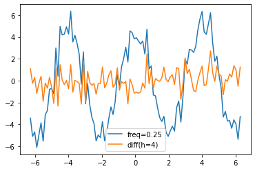

```python
ax.figure
```

## Differencing

Because diﬀerencing plays a central role in time series analysis, it receives its own notation. Before introduce formally the differences, we define the backshift operator (or lag operator) as

$$ B X_t = X_{t-1} $$

and extend it to powers $B^2 X_t = B(B X_t) = B X_{t-1} = X_{t-2}$, and so on. Thus

$$ B^k X_t = X_{t-k} $$

The idea of an inverse operator can also be given if we require $B^{-1} B$=1, so that

$$ X_t = B^{-1}B X_t = B^{-1} X_{t−1} $$

That is, $B^{-1}$ is the forward-shift operator.

Then, we can express a difference of order $d$ in terms of the backshift operator as

$$ \nabla^d=(1-B)^d $$

where we may expand the operator $(1 − B)^d$ algebraically to evaluate for higher integer values of $d$.